# Manejo Florestal

UNIDADE 1 - INTRODUÇÃO AO MANEJO FLORESTAL

Prof. Dr. Gabriel Agostini Orso

gabriel.orso@ufsm.br

Universidade Federal de Santa Maria

11 de agosto de 2026

# AULA DE HOJE

## Aula de hoje

- **UNIDADE 1 - INTRODUÇÃO AO MANEJO FLORESTAL**
  - 1.1 - Conceitos do manejo florestal
  - 1.2 - Histórico do manejo florestal

# INTRODUÇÃO

## Introdução

O que é o manejo florestal?

## Introdução

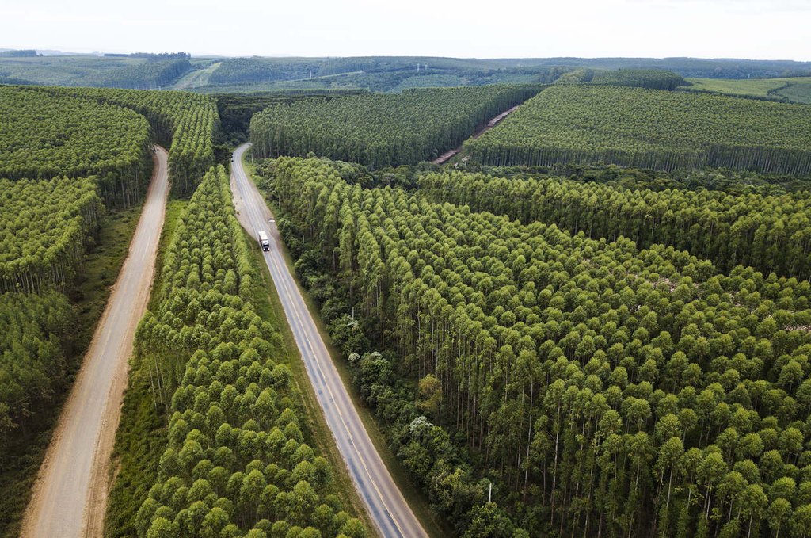

Povoamento de eucalipto. [Fonte](https://blog.klabin.com.br/documents/55324/0/Unidade+Florestal-Mosaico-Eucalipto-Fot%C3%B3grafo+n%C3%A3o+identificado-2020_%287%29_Easy-Resize.com.jpg/d191ec3f-69e3-bccf-ef4f-d4e301e1a961?t=1727466537907)

## Introdução

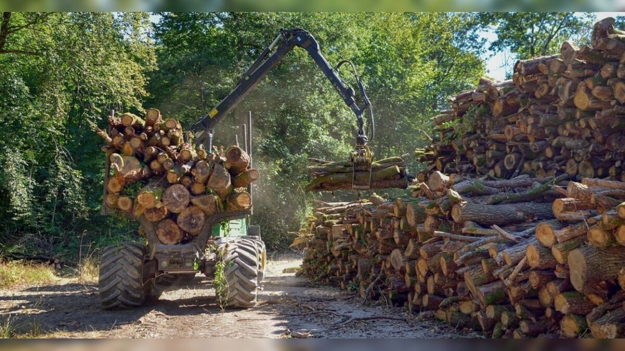

Produção madeireira. [Fonte](https://roderbrasil.com.br/blog/wp-content/uploads/2025/07/O-que-e-manejo-florestal-sustentavel-e-como-a-mecanizacao-contribui-para-isso-1-1.jpg)

## Introdução

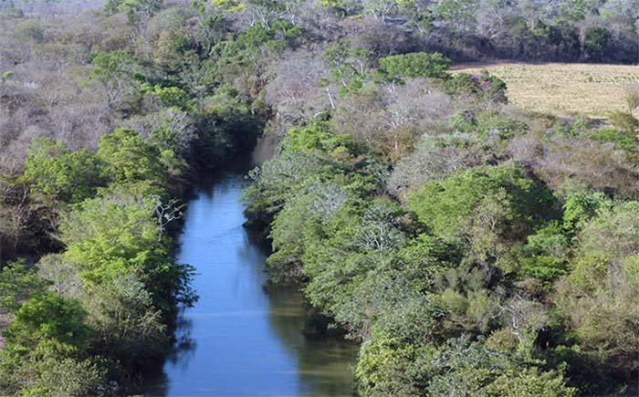

Área de Preservação Permanente. [Fonte](https://viladeutopia.com.br/wp-content/uploads/2022/04/APP.jpg)

## Introdução

O manejo florestal está centrado no conceito da utilização dos recursos florestais de forma sensata e sustentada, de modo que as gerações futuras possam usufruir pelo menos dos mesmos benefícios da geração presente.

**Nota**

Similar ao que prevê o artigo 225º da Constituição Federal.

## Introdução

### Quais são os recursos florestais?

- Madeira serrada
- Celulose
- Lenha
- Carvão
- Taninos
- Extrativos
- Resina
- Frutos
- Serviços Ecossistêmicos
- Outros…

## Introdução

### Quais são os recursos florestais?

- Madeira serrada
- Celulose
- Lenha
- Carvão
- Taninos
- Extrativos
- Resina
- Frutos
- Serviços Ecossistêmicos
- Outros…

## Introdução

A ideia de outros bens e serviços é relativemente recente.

Historicamente o manejo florestal nasceu de uma demanda por madeira.

# CONCEITOS

## Conceitos

**Conceito de manejo florestal**

É o conjunto de artes e técnicas que permitem a organização da produção florestal com a base do rendimento contínuo. (Society of American Foresters, Meyer, 1961)

**Conceito de manejo florestal**

Trata de levantamentos periódicos do estado atual dos povoamentos, do planejamento a médio e longo prazo, da revisão periódica da produção da propriedade florestal. (Mantel, 1959)

**Conceito de manejo florestal**

Trata da organização ótima de uma propriedade florestal, através de planejamento e controles dos efeitos, a serem feitos periodicamente, com a intenção de preservação ou aumento duradouro da produção florestal. (Richer, 1963)

**Conceito de manejo florestal**

É definido como a maneira de dirigir uma empresa florestal. (Meyer, 1961)

Dirigir: dar ordens e controlar

## Conceitos

A direção de uma empresa deve cumprir algumas exigências básicas:

1. Manejo sustentado: Em longo prazo obter pelo menos os mesmos benefícios, como atualmente.
2. Manejo racional: As informações disponíveis devem ser bem aproveitadas e visar um objetivo específico.

## Conceitos

3. Manejo funcional: Quatro funções - Análise, Planejamento, Controle e Correção.
   1. Análise: conhecer a situação atual da empresa: Inventário florestal, situação financeira e organizatória.
   2. Planejamento: Planejar as medidas, para alcançar os seus objetivos.
   3. Controle: Sistema de registro: contabilidade, registros dendrométricos dos talhões, *etc.*.
   4. Correção: Constante correção de problemas identificados, melhoria de processos.

## Conceitos

4. Manejo integral: Observá-lo sob quatro aspectos:
   1. Aspecto físico: Analisa-se a empresa em unidades físicas, como hectare $ha$, $m³$, $km$, *etc.*.
   2. Aspecto financeiro: Estrutura e funcionamento da empresa deve ser planejada e controlada em unidades financeiras.
   3. Aspecto organizatório: Elementos humanos da empresa, as suas funções, qualificações, subordinações, *etc.*
   4. Aspecto informativo: Uso de informações disponíveis. As ordens devem ser passadas por informações normativas, descritivas da situação.

## Conceitos

**.**

Vejam que o termo de manejo é utilizado com dois sentidos diferentes.

1. Como tratamento do povoamento florestal.
2. Como administração ou direção de uma empresa florestal. O manejo abrange todas as funções do gerente de uma empresa.

Faz parte da administração ou gerência o ordenamento da produção.

**Ordenamento $\neq$ Manejo**

- Ordenamento: é **somente uma** das tarefas - ordenar a produção.
- Manejo florestal: engloba **todas** as funções da gerência.

# Histórico

## Histórico do Manejo Florestal

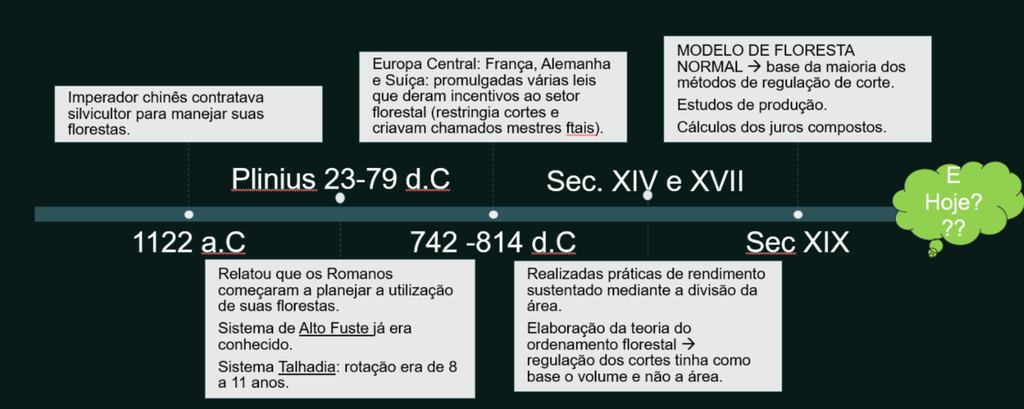

Linha do Tempo

## Histórico do Manejo Florestal

O histórico de desmatamento para fins bélicos, incêndios *etc.* trouxe uma severa escassez de madeira, principalmente a partir do século XVII.

A noção de ordenamento florestal foi uma das principais contribuições para a produção sustentada.

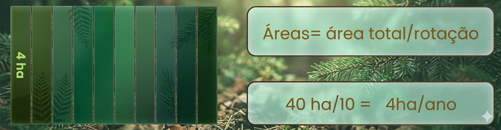

Partição Florestal

## Histórico do Manejo Florestal

**Exercício**

Qual a necessidade de reflorestamento de um município para atender a demanda sustentada anual de matéria prima?

- População: 200 mil habitantes
- Espécie: *Eucalyptus* sp.
- Rotação: 7 anos
- IMA 7 anos: 30 m³/ha/ano

## Histórico do Manejo Florestal

Em 1789 foi fundada a primeira escola florestal.

O fundador da escola, G. L. Hartig, formulou em 1804 a ideia básica do manejo sustentado.

**G. L. Harting**

*“Manejar a floresta de maneira que os descendentes possam obter pelo menos os mesmos benefícios que a geração vigente.”*

## Histórico do Manejo Florestal

[figure not shown]

Primeiros Livros relacionados ao manejo florestal e silvicultura. Von Carlowitz (1713), Hartig (1791) e Cotta (1817). Adaptado de Arce e Dobner Jr. (2023).

## Histórico do Manejo Florestal

- No século XIX foi formulada a ideia da Floresta Normal por Hundeshagen e Meyer.

**Modelo de Floresta Normal**

Ainda serve de base para maioria dos métodos de regulação de corte atualmente.

- Após a segunda guerra mundial surge a Pesquisa Operacional (Inglaterra e EUA). Modelos matemáticos, otimização linear, otimização dinâmica, sistema PERT/CPM e técnicas de simulação.

## Histórico do Manejo Florestal

O Manejo Florestal no Brasil teve como precursor Navarro de Andrade, que trouxe a eucaliptocultura para o país.

[figure not shown]

Obra original de Navarro de Andrade. Adaptado de Arce e Dobner Jr. (2023).

## Histórico do Manejo Florestal

Século XXI: Uso de inteligência artificial

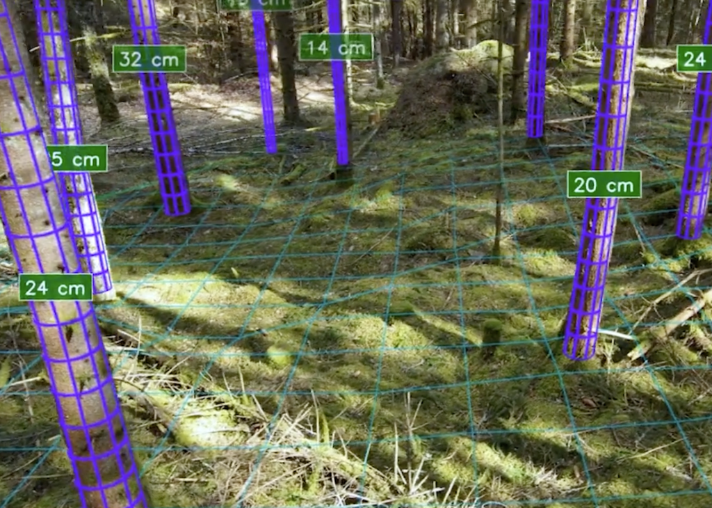

[Aplicativo Katam](https://www.katam.se/wp-content/uploads/2022/09/Untitled-8.png)

# MANEJO E CIÊNCIAS RELACIONADAS

## Áreas Relacionadas

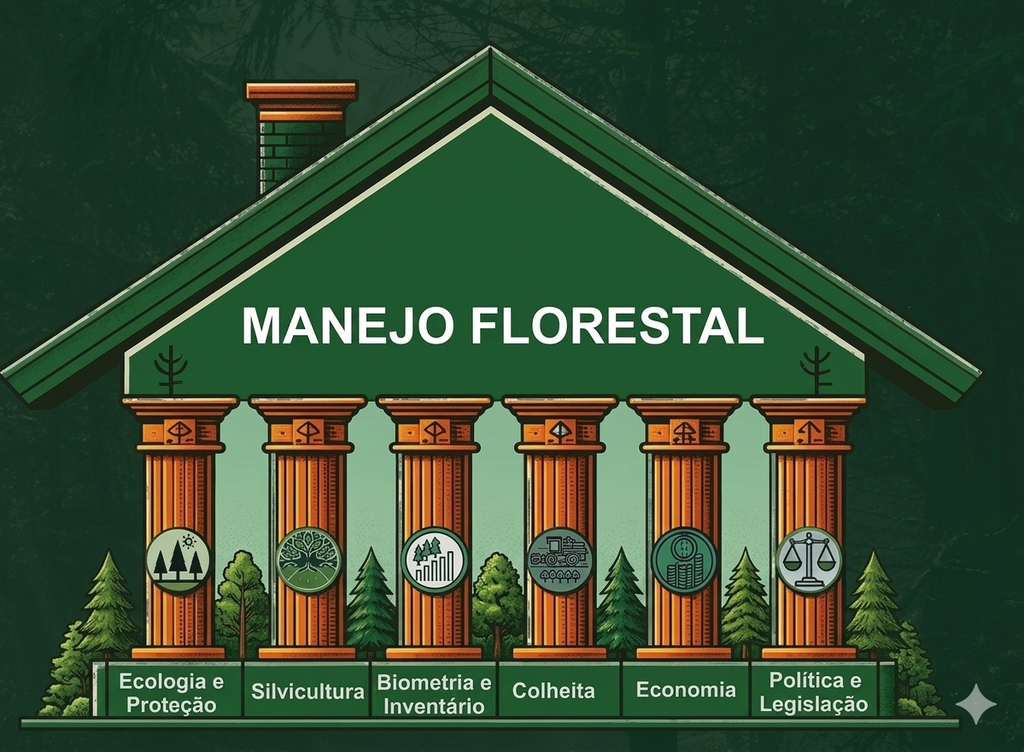

Áreas relacionadas com o manejo florestal

## Áreas Relacionadas

- Ecologia: Antecede o manejo. Identifica a mapeia o habitat, avalia as influências ecológicas sobre o crescimento das árvores.
- Silvicultura: Todos os aspectos silviculturais.
- Biometria e Inventário: Fornecem dados de crescimento e produção.
- Proteção Florestal: Abrange todos os aspectos a amenizar riscos contra fogo, insetos *etc.*.
- Economia: Referem à lei de oferta e procura, comercialização, custos e rentabilidade.
- Colheita Florestal: Aspectos relacionados à exploração, custos, abastecimento *etc.*.
- Política e Legislação: Traçam certas margens de movimentação para os planejamentos do manejo florestal.